# PracticalMachineLearning

Ziqi-jiang

1/17/2019

## Goal

The goal of this project is to predict the manner in which people did the exercise. This is the “classe” variable in the training set.

## Report

### How I built models

I built two training data sets: training1 and training2 after dealing with missing values. For each training data set, what I did as follows:

1. Preprocess: Checking Zero- and Near Zero-Variance Predictors, Creating dummy variables
2. Exploratory Analysis: Checking linear dependencies, Calculating correlation using Simple Linear Regression and Chi-Squared, Setting PCA and Cross-Validation (Bootstrap and 10-fold Cross Validation)
3. Model fitting & stacking: Splitting dataset into Training sub-dataset and Validation sub-dataset, fitting RandomForest, Linear Discriminant Analysis Model, Penalized Multinomial Regression model, stacking them together.
4. Model selection: Compare the Accuracies and their p-values

### How I used cross validation

I used cross validation during variable selection. I repeated bootstrap for 25 times to do the cross-validation for small training dataset, which is training2. And I repeated 10-fold cross-validation for 3 times to the cross-validation for dataset with plenty of data, which is training1.

### The expectation on out of sample error

I expect the out of sample error to be small, although larger than in sample error(from the result of validation).

I split the dataset into training dataset and validation dataset. Before testing, I used the validation dataset to test the models, which could give me a general idea about how the models might perform. During being validated, the final model I chose, the Random Forest Model generated from training1 dataset, resulted in a high accuracy.

I looked into the test dataset, this data is not greatly different from the training data. So, I suppose the model which perform well when dealing with training data can handle this test data, too.

## Preprocessing

### Missing Values

In the result of the summary, it is found that some columns only contains NAs. I’m removing these empty columns.

#### Conclusion

As we can see, for these missing values: 1. For these variables, they either contains no missing value or contains less than 3% non-na values. 2. There is no missing value in the response variable.

#### How to deal

Currently, I decide to take two different approaches to deal with these missing values: 1.Remove all the columns with NAs. 2.Remove all the rows with NAs.

#### Why I am dealing in this way

There are two reasons: 1. The records with missing values takes a huge propotion of this training dataset and the proportions are close to each other. 2. For these records, they don’t have missing value in the response variable. 3. For these variables, in the comparison with other variables, they contains too little information, which may induce bias or mistake while constructing predictions.

### Zero- and Near Zero-Variance Predictors

In the summary for the second training set, I found there are several columns contains just one value, which is useless for fitting models.

#### How to deal

I removed this kind of columns in the second training.

#### Why I am dealing in this way

In some situations, the data generating mechanism can create predictors that only have a single unique value (i.e. a “zero-variance predictor”). For many models (excluding tree-based models), this may cause the model to crash or the fit to be unstable.

Similarly, predictors might have only a handful of unique values that occur with very low frequencies.

The concern here that these predictors may become zero-variance predictors when the data are split into cross-validation/bootstrap sub-samples or that a few samples may have an undue influence on the model. These “near-zero-variance” predictors may need to be identified and eliminated prior to modeling.

```r
library(caret)
nzv1 = nearZeroVar(training1, saveMetrics = TRUE)
nzv2 = nearZeroVar(training2, saveMetrics = TRUE)

for(i in length(colnames(training2)):1){
        if(all(training2[,i]==training2[1,i])){
                training2[,i] = NULL
        }
}
```

### Creating Dummy Variables (Training2)

```r
dummies2 = dummyVars(classe ~ ., data = training2)
training2_dummy = data.frame(predict(dummies2, newdata = training2))
nzv2_dummy = nearZeroVar(training2_dummy, saveMetrics = TRUE)

training2_dummy = training2_dummy[,!nzv2_dummy$nzv]

summary(training2_dummy)
```

```
##  user_name.carlitos user_name.charles user_name.eurico user_name.pedro
##  Min.   :0.0000     Min.   :0.0000    Min.   :0.0000   Min.   :0.0000
##  1st Qu.:0.0000     1st Qu.:0.0000    1st Qu.:0.0000   1st Qu.:0.0000
##  Median :0.0000     Median :0.0000    Median :0.0000   Median :0.0000
##  Mean   :0.2074     Mean   :0.3272    Mean   :0.2166   Mean   :0.2488
##  3rd Qu.:0.0000     3rd Qu.:1.0000    3rd Qu.:0.0000   3rd Qu.:0.0000
##  Max.   :1.0000     Max.   :1.0000    Max.   :1.0000   Max.   :1.0000
##  raw_timestamp_part_1 raw_timestamp_part_2 cvtd_timestamp.02.12.2011.14.57
##  Min.   :1.322e+09    Min.   :568296       Min.   :0.0000
##  1st Qu.:1.323e+09    1st Qu.:968279       1st Qu.:0.0000
##  Median :1.323e+09    Median :980350       Median :0.0000
##  Mean   :1.323e+09    Mean   :972647       Mean   :0.1475
##  3rd Qu.:1.323e+09    3rd Qu.:990916       3rd Qu.:0.0000
##  Max.   :1.323e+09    Max.   :998801       Max.   :1.0000
##  cvtd_timestamp.02.12.2011.14.58 cvtd_timestamp.05.12.2011.11.24
##  Min.   :0.0000                  Min.   :0.000
##  1st Qu.:0.0000                  1st Qu.:0.000
##  Median :0.0000                  Median :0.000
##  Mean   :0.1244                  Mean   :0.106
##  3rd Qu.:0.0000                  3rd Qu.:0.000
##  Max.   :1.0000                  Max.   :1.000
##  cvtd_timestamp.05.12.2011.11.25 cvtd_timestamp.05.12.2011.14.23
##  Min.   :0.00000                 Min.   :0.0000
##  1st Qu.:0.00000                 1st Qu.:0.0000
##  Median :0.00000                 Median :0.0000
##  Mean   :0.09677                 Mean   :0.1244
##  3rd Qu.:0.00000                 3rd Qu.:0.0000
##  Max.   :1.00000                 Max.   :1.0000
##  cvtd_timestamp.05.12.2011.14.24 cvtd_timestamp.28.11.2011.14.13
##  Min.   :0.0000                  Min.   :0.00000
##  1st Qu.:0.0000                  1st Qu.:0.00000
##  Median :0.0000                  Median :0.00000
##  Mean   :0.1014                  Mean   :0.06452
##  3rd Qu.:0.0000                  3rd Qu.:0.00000
##  Max.   :1.0000                  Max.   :1.00000
##  cvtd_timestamp.28.11.2011.14.14   num_window      roll_belt
##  Min.   :0.0000                  Min.   :  2.0   Min.   :-27.80
##  1st Qu.:0.0000                  1st Qu.:146.0   1st Qu.:  1.48
##  Median :0.0000                  Median :352.0   Median :117.00
##  Mean   :0.1152                  Mean   :418.5   Mean   : 71.31
```

[output cut: 274 more lines]

```
##  Max.   :197.50781   Max.   :39009.3   Max.   : 1.16000
##  gyros_forearm_y    gyros_forearm_z    accel_forearm_x   accel_forearm_y
##  Min.   :-5.19000   Min.   :-2.30000   Min.   :-464.00   Min.   :-406.0
##  1st Qu.:-1.75000   1st Qu.:-0.26000   1st Qu.:-186.00   1st Qu.: -53.0
##  Median : 0.00000   Median : 0.03000   Median : -74.00   Median : 118.0
##  Mean   :-0.07267   Mean   : 0.06853   Mean   : -92.55   Mean   : 103.7
##  3rd Qu.: 1.69000   3rd Qu.: 0.41000   3rd Qu.:  48.00   3rd Qu.: 276.0
##  Max.   : 4.74000   Max.   : 2.23000   Max.   : 244.00   Max.   : 512.0
##  accel_forearm_z   magnet_forearm_x magnet_forearm_y magnet_forearm_z
##  Min.   :-329.00   Min.   :-782.0   Min.   :-835.0   Min.   :-577.0
##  1st Qu.:-182.00   1st Qu.:-626.0   1st Qu.:-161.0   1st Qu.:  62.0
##  Median :  -6.00   Median :-430.0   Median : 442.0   Median : 454.0
##  Mean   : -38.88   Mean   :-339.5   Mean   : 293.1   Mean   : 311.2
##  3rd Qu.:  43.00   3rd Qu.:-154.0   3rd Qu.: 733.0   3rd Qu.: 575.0
##  Max.   : 254.00   Max.   : 625.0   Max.   :1220.0   Max.   : 856.0
```

## Exploratory Analysis

To analyze the data more easily, I split the training1 data set into categorical variables and numerical variables.

### Examing correlation

#### Linear Dependency check (Training2)

```r
descrCor2 = cor(training2_dummy)
summary(descrCor2[upper.tri(descrCor2)])
```

```
##      Min.   1st Qu.    Median      Mean   3rd Qu.      Max.
## -0.993973 -0.087939  0.005117  0.011720  0.096406  1.000000
```

```r
highlyCorDescr2 = findCorrelation(descrCor2, cutoff = .75)
training2_dummy = training2_dummy[,-highlyCorDescr2]
descrCor2_Aft = cor(training2_dummy)
summary(descrCor2_Aft[upper.tri(descrCor2_Aft)])
```

```
##      Min.   1st Qu.    Median      Mean   3rd Qu.      Max.
## -0.746597 -0.079576  0.001603  0.004394  0.083167  0.745385
```

```r
comboInfo2 = findLinearCombos(training2_dummy)
comboInfo2$remove
```

#### Numeric Variables (Training1)

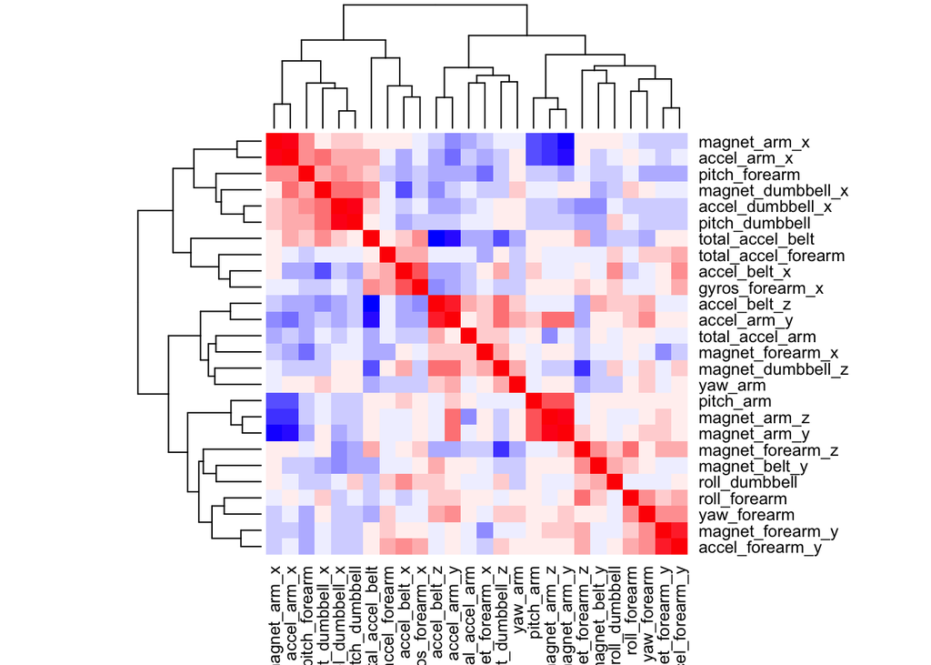

```r
# Numeric Variables in training1
# Correlation with the response
for(i in (length(colnames(training1_num))-1):1){
        p = (summary(lm(training1_num[,i]~training1_num$classe))$coefficients[,4]<0.05)
        if(all(p)){
                next()
        } else {
                training1_num[,i] = NULL
        }
}

# Correlation with other predictor variables
n = ncol(training1_num)
m = n-1
training1_num_pred = data.frame(training1_num[,1:m])
cormat = signif(cor(training1_num_pred),2)
col = colorRampPalette(c("blue", "white", "red"))(20)
heatmap(cormat, col=col,symm = TRUE)
```

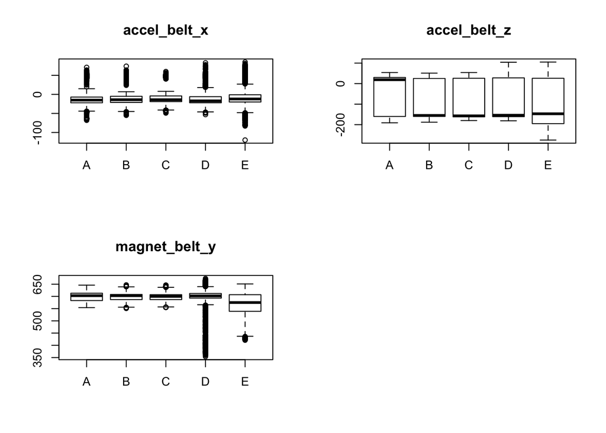

```r
cordf = data.frame(cormat)
cor_dorp_v = c()
for (i in colnames(cordf)){
        for (j in row.names(cordf)){
                if (i!=j){
                      if (abs(cordf[j,i]) > 0.95){
                        pi = summary(lm(training1_num[,i]~training1_num$classe))$coefficients[,4]
                        pj = summary(lm(training1_num[,j]~training1_num$classe))$coefficients[,4]
                        if (mean(pi)>mean(pj) & !(i %in% cor_dorp_v)){
                                cor_dorp_v = append(cor_dorp_v,i)
                        } else {
                                if (!(j %in% cor_dorp_v))
                                cor_dorp_v = append(cor_dorp_v,j)
                        }
                              }
                }

        }
}

for (i in cor_dorp_v){
        training1_num[,i] = NULL
}

#par(mfrow=c(2,2))
#for (i in 1:(length(colnames(training1_num))-1)){
#        boxplot(training1_num[,i]~training1_num$classe,main = colnames(training1_num)[i])
#        if (i%%4 == 0){
#           par(mfrow=c(2,2))
#        }
#}

#Because of the limitation on the number of plots, I just show 3 here
par(mfrow=c(2,2))
for (i in 1:3){
        boxplot(training1_num[,i]~training1_num$classe,main = colnames(training1_num)[i])
}
```

#### How to deal

Between predictors and response, I constucted simple linear regression between one numeric predictor variable and the response variable and checked the p-value of the regressor. If the p-value is smaller than 0.05, I consider the relationship is statistically significant.

Between predictors, I calculate the correlation between two predictor variables. When the correlation statistic is larger than 0.95, which means they are almost the same, in these two predictors, I remove the predictor with less significant relationship with response.

After removing variables which have strong correlation with another predictor, I use boxplot to visualize and check the relationship betweeen predictor and response.

#### Why I am dealing in this way

Between predictors and response, because the response variable is categorical while most other variables are numeric. And during this stage, I hope the model I am using to be as simple as possible, so that it enables the outcome to be as interpretable as possible. As a result, I choose simple linear regression model.

Between predictors, because I use simple linear regression to exam the relationship between predictors and response, which left the correlation between predictor out. I need to find the significant correlation.

#### Categorical Variables (Training1)

#### How to deal

Between predictors, I used chi-square to check the correlation between predictors.

According to the chi-squares and their p-values, I didn’t remove any predictor.

#### Why I am dealing in this way

Between predictors, because I need to get a general idea about the correlation among predictors. And these predictors are categorical. So, I choose chi-square test.

### Creating Dummy Variables (Training1)

```r
training1_num$classe = NULL
training1_Aft = cbind(training1_num,training1_cat)

dummies1 = dummyVars(classe ~ ., data = training1_Aft)
training1_dummy = data.frame(predict(dummies1, newdata = training1_Aft))
training1_dummy$classe = training1$classe
```

### PCA & Bootstrap & Cross-Validation

#### How to deal (training1)

I repeated 10-fold cross-validation for three times to find the best PCA for training1 dataset.

#### Why I am dealing in this way (training1)

Because there are only above plenty of observations in training1 dataset. After taking the complexity of computing and the accuracy, I choose 10-fold cross-validation.

```r
ctrl_PCA_1 <- trainControl(method = "repeatedcv",
                           number = 10,
                           repeats = 3,
                           classProbs = TRUE,
                           preProcOptions = list(thresh = 0.85)
                     )
```

#### How to deal (training2)

I used bootstrap to find the best PCA for training2 dataset. The bootstrap was repeated 25 times.

#### Why I am dealing in this way (training2)

Because there are only above 200 observations in training2 dataset. I’m using bootstrap to maximize of the data I have.

```r
ctrl_PCA_2 <- trainControl(method = "boot",
                     classProbs = TRUE,
                     preProcOptions = list(thresh = 0.85)
                     )
```

## Spliting validation dataset

### Spliting validation dataset for training1

```r
set.seed(1)
trainIndex1 <- createDataPartition(training1_dummy$classe, p = .75,
                                  list = FALSE,
                                  times = 1)
Training1_Split <- training1_dummy[ trainIndex1,]
Validation1_Split  <- training1_dummy[-trainIndex1,]
```

```r
Training1_Split_linear = data.frame(Training1_Split)
Training1_Split_linear$classe = NULL
descrCor1_Split = cor(Training1_Split_linear)
summary(descrCor1_Split[upper.tri(descrCor1_Split)])
```

```
##      Min.   1st Qu.    Median      Mean   3rd Qu.      Max.
## -1.000000 -0.088409 -0.026435 -0.007836  0.044183  0.913844
```

```r
highlyCorDescr1_Split = findCorrelation(descrCor1_Split, cutoff = .75)
Training1_Split_linear = Training1_Split_linear[,-highlyCorDescr1_Split]
descrCor1_Split_Aft = cor(Training1_Split_linear)
summary(descrCor1_Split_Aft[upper.tri(descrCor1_Split_Aft)])
```

```
##     Min.  1st Qu.   Median     Mean  3rd Qu.     Max.
## -0.58161 -0.07907 -0.02885 -0.01268  0.03374  0.65491
```

```r
comboInfo1_Split = findLinearCombos(Training1_Split_linear)
Training1_Split_linear = Training1_Split_linear[,-comboInfo1_Split$remove]

Training1_Split_linear$classe = Training1_Split$classe
```

#### How to deal

I splitted the training1 dataset into Training1_Split and Validation1_Split with the rate between them being 0.75 : 0.25, considering the response variable. The correlation and colinearity are checked again.

#### Why I am dealing in this way

I’m splitting the dataset to set a measure for model selection. I’m splitting in this proportion because the data set is not too small.

### Spliting validation dataset for training2

```r
training2_dummy$classe = training2$classe
set.seed(1)
trainIndex2 <- createDataPartition(training2_dummy$classe, p = .85,
                                  list = FALSE,
                                  times = 1)
Training2_Split <- training2_dummy[ trainIndex2,]
Validation2_Split  <- training2_dummy[-trainIndex2,]
```

```r
Training2_Split_linear = data.frame(Training2_Split)
Training2_Split_linear$classe = NULL
descrCor2_Split = cor(Training2_Split_linear)
summary(descrCor2_Split[upper.tri(descrCor2_Split)])
```

```
##       Min.    1st Qu.     Median       Mean    3rd Qu.       Max.
## -0.7462517 -0.0826459  0.0009396  0.0044531  0.0874632  0.9199447
```

```r
highlyCorDescr2_Split = findCorrelation(descrCor2_Split, cutoff = .75)
Training2_Split_linear = Training2_Split_linear[,-highlyCorDescr2_Split]
descrCor2_Split_Aft = cor(Training2_Split_linear)
summary(descrCor2_Split_Aft[upper.tri(descrCor2_Split_Aft)])
```

```
##       Min.    1st Qu.     Median       Mean    3rd Qu.       Max.
## -0.7462517 -0.0830044  0.0009998  0.0041846  0.0865032  0.7469815
```

```r
comboInfo2_Split = findLinearCombos(Training2_Split_linear)
comboInfo2_Split$remove
```

```r
Training2_Split_linear$classe = Training2_Split$classe
```

#### Why I am dealing in this way

I’m splitting the dataset to set a measure for model selection. I’m splitting in this proportion because the data set is very small. I need as much data as possible to train the model.

## Model Fitting

#### How to deal

I choose three different models: RandomForest, Linear Discriminant Analysis Model, Penalized Multinomial Regression. And I fitted these three models to training1 and training2 respectively. Then, I stacked them together in the attempt to get a better result. Finally, I compared the validation results for training1 and training2 individually and choosed one to test.

#### Why I am dealing in this way

First of all, the response variable is categorical. What’s more, my goal is to predict and these three classification models are consider to perform good in accuracy of prediction.

### Model Fitting for training1

#### RandomForest Model (training1)

```r
ModelFit_rf_1 = train(classe~., Training1_Split_linear,
                     method = "rf",
                     trControl = ctrl_PCA_1)

Pred_rf_1 = predict(ModelFit_rf_1, newdata = Validation1_Split)

CM_rf_1 = confusionMatrix(data = Pred_rf_1, reference = Validation1_Split$classe)
```

#### Linear Discriminant Analysis Model (training1)

```r
ModelFit_lda_1 = train(classe~., Training1_Split_linear,
                     method = "lda",
                     trControl = ctrl_PCA_1)
```

[output not shown]

```r
Pred_lda_1 = predict(ModelFit_lda_1, newdata = Validation1_Split)

CM_lda_1 = confusionMatrix(data = Pred_lda_1, reference = Validation1_Split$classe)
```

#### Penalized Multinomial Regression (training1)

```r
ModelFit_multinom_1 = train(classe~., Training1_Split_linear,
                     method = "multinom",
                     trControl = ctrl_PCA_1)
Pred_multinom_1 = predict(ModelFit_multinom_1, newdata = Validation1_Split)

CM_multinom_1 = confusionMatrix(data = Pred_multinom_1, reference = Validation1_Split$classe)
```

#### Stacking RF,LDA, PMR (training1)

```r
Training1_Stack = data.frame(Pred_rf_1,Pred_lda_1,Pred_multinom_1,
                             classe = Validation1_Split$classe)

ModelFit_Stack_1 = train(classe~.,
                         method = "gam",
                         data = Training1_Stack)
```

[output not shown]

[output cut: 97 more lines]

[output not shown]

```r
Pred_Stack_1 = predict(ModelFit_Stack_1,Training1_Stack)

CM_Stack_1 = confusionMatrix(data = Pred_Stack_1,
                             reference = Validation1_Split$classe)
```

### Model Fitting for training2

#### RandomForest Model (training2)

```r
ModelFit_rf_2 = train(classe~., Training2_Split_linear,
                     method = "rf",
                     trControl = ctrl_PCA_2)

Pred_rf_2 = predict(ModelFit_rf_2, newdata = Validation2_Split)

CM_rf_2 = confusionMatrix(data = Pred_rf_2, reference = Validation2_Split$classe)
```

#### Linear Discriminant Analysis Model (training2)

```r
ModelFit_lda_2 = train(classe~., Training2_Split_linear,
                     method = "lda",
                     trControl = ctrl_PCA_2)
Pred_lda_2 = predict(ModelFit_lda_2, newdata = Validation2_Split)

CM_lda_2 = confusionMatrix(data = Pred_lda_2, reference = Validation2_Split$classe)
```

#### Penalized Multinomial Regression (training2)

```r
ModelFit_multinom_2 = train(classe~., Training2_Split_linear,
                     method = "multinom",
                     trControl = ctrl_PCA_2)
Pred_multinom_2 = predict(ModelFit_multinom_2, newdata = Validation2_Split)

CM_multinom_2 = confusionMatrix(data = Pred_multinom_2, reference = Validation2_Split$classe)
```

#### Stacking RF,LDA, PMR (training2)

```r
Training2_Stack = data.frame(Pred_rf_2,Pred_lda_2,Pred_multinom_2,
                             classe = Validation2_Split$classe)

ModelFit_Stack_2 = train(classe~.,
                         method = "gam",
                         data = Training2_Stack)
```

[output not shown]

[output cut: 55 more lines]

[output not shown]

```r
Pred_Stack_2 = predict(ModelFit_Stack_2,Training2_Stack)

CM_Stack_2 = confusionMatrix(data = Pred_Stack_2,
                             reference = Validation2_Split$classe)
```

### Model Selection

```r
result_MF = rbind(CM_rf_1$overall[c(1,6)],
                  CM_lda_1$overall[c(1,6)],
                  CM_multinom_1$overall[c(1,6)],
                  CM_Stack_1$overall[c(1,6)],
                  CM_rf_2$overall[c(1,6)],
                  CM_lda_2$overall[c(1,6)],
                  CM_multinom_2$overall[c(1,6)],
                  CM_Stack_2$overall[c(1,6)])
result_MF = cbind(c("1RF","1LDA","1Multinom","1Stack",
                    "2RF","2LDA","2Multinom","2Stack"),
                  result_MF)
result_MF
```

```
##                  Accuracy            AccuracyPValue
## [1,] "1RF"       "0.979404567699837" "0"
## [2,] "1LDA"      "0.746533442088091" "0"
## [3,] "1Multinom" "0.783034257748777" "0"
## [4,] "1Stack"    "0.472675367047308" "7.73353142355737e-171"
## [5,] "2RF"       "0.774193548387097" "2.73892338416152e-09"
## [6,] "2LDA"      "0.838709677419355" "2.06751925781197e-11"
## [7,] "2Multinom" "0.612903225806452" "3.27339939672064e-05"
## [8,] "2Stack"    "0.419354838709677" "0.0368566810698118"
```

#### How to deal

I choose RandomForest model trained by training1 dataset.

#### Why I am dealing in this way

As we can see from this summary, for training1, RandomForest Model got a really impressive accuracy and for training2, Linear Discriminant Analysis Model got a good result. What’s more, the p-value of these results are really small.

So, I wanted to stack these two models together using Validation1 dataset and see which is the best in the three. But I need to check whether I can use the existing validation datasets.

```r
all(ModelFit_lda_2$coefnames%in%colnames(Validation1_Split))
```

```
## [1] FALSE
```

```r
all(ModelFit_rf_1$coefnames%in%colnames(Validation2_Split))
```

```
## [1] FALSE
```

It turned out that I cannot use neither Validation1 nor Validation2. And LDA can only apply to the observations without missing values, which will results in prediction in different length or I have to use very small dataset to stack.

So, I choose Random Forest model trained by training1 dataset.

## Test

Firstly, I need to reconstruct testing dataset.

```r
## dealing with missing values
for(i in length(colnames(testing)):1){
        if(all((is.na(testing[,i])))){
                testing[,i] = NULL
        }
}

library(mlr)
library(dummies)
training1_cat$classe = NULL
for (i in c("user_name","cvtd_timestamp")){
      testing = cbind(testing, createDummyFeatures(testing, cols = i))
      testing[,i] = NULL
}

testing = cbind(testing, dummy(testing$new_window,sep = "."))
testing$new_window.no = testing$testing.no
adding = colnames(training1_dummy)[!colnames(training1_dummy)%in%colnames(testing)]
adding = adding[adding != "classe"]
adding_df = data.frame(matrix(0, nrow=nrow(testing), ncol=length(adding)))
colnames(adding_df) = adding
testing = cbind(testing,adding_df)
```

### How to deal

1. Missing Values:

Because there are a lot of NA values in the testing data set and some columns only contain NA. I removed these columns.

2. Categorical Variables:

Because there are several categorical variables which will be useful in the prediction. I transformed them into dummy variables.

### Why I am dealing in this way

1. Missing Values:

I am doing this to lessen the computing complexity and enhance the efficiency.

2. Categorical Variables:

The model I chose is bulit on the base of a cleaned data set. So, if I want to use it to predict, I also need to clean the data.

### Test Prediction Result

```r
Pre_test = predict(ModelFit_rf_1, testing)

Pre_test
```

```
##  [1] B A B A A E D B A A B C B A E E A B B B
## Levels: A B C D E
```

### Expectation to Prediction Result

```r
min=c()
Q1=c()
med=c()
mean=c()
Q3=c()
max=c()

Training1_Split_linear_t = data.frame(Training1_Split_linear)
testing_t = data.frame(testing)
Training1_Split_linear_t$new_window.no=NULL
Training1_Split_linear_t$new_window = NULL
Training1_Split_linear_t$classe = NULL
testing_t$new_window.no=NULL
testing_t$new_window = NULL

for (n in colnames(Training1_Split_linear_t)){
        Train = summary(Training1_Split_linear_t[,n])
        Test = summary(testing_t[,n])
        min = (Train[1] <= Test[1])
        max = (Train[6] >= Test[6])
        print(all(min,max))
}
```

```
## [1] TRUE
## [1] TRUE
## [1] TRUE
## [1] TRUE
## [1] TRUE
## [1] TRUE
## [1] TRUE
## [1] TRUE
## [1] TRUE
## [1] TRUE
## [1] TRUE
## [1] TRUE
## [1] TRUE
## [1] TRUE
## [1] TRUE
```

[output cut: 24 more lines]

```r
sum(testing$new_window.no)<=sum(Training1_Split_linear$new_window.no)
```

```
## [1] TRUE
```